# Cyclistic User Behavior Exploratory Data Analysis

JohnPaul Medina

2025-03-11

## Exploratory Data Analysis (EDA) Log Introduction

### Objective:

This **Exploratory Data Analysis (EDA)** aims to identify key **behavioral differences** between casual riders and annual members, helping shape a marketing strategy to encourage casual riders to convert to membership.

### EDA Focus Areas

The analysis is structured around the following key focus points:

1. **User Distribution Analysis**
- Compare the **proportion of casual vs. member riders.**
- Identify the **scale of potential member conversions**
2. **Ride duration Patterns**
- Compare **summary statistics of ride duration** across user types.
- Determine whether casual **riders take longer trips** and how this insight can can be used for marketing.
3. **Time-Based Trends in Service Usage**
- **Hourly and weekly heatmaps*** to analyze user riding pattern at different times of the day and days of the week.
- **Seasonal trends** by analyzing monthly ride distributions to evaluate peak demand periods.
4. **Bike Type Preference & Usage Patterns**
- Identify **bike type preference** between causal and member riders.
- Explore **ride duration patterns across different bike types.**

Each of these areas will provide insights to support **marketing strategies**, optimize **pricing model**, and improve **customer engagement initiatives.**

First we will take a look at **rider type distribution** to understand the **size of our data** and how casual versus member riders are distributed.

```r
if (!exists("cleaned_data")) {
  cleaned_data <- readRDS(cleaned_data_rds)
}

# Compute Rider Counts
member_count <- sum(cleaned_data$member_casual == "member")
casual_count <- sum(cleaned_data$member_casual == "casual")
total_accounts <- member_count + casual_count

# Create a summary table
rider_type_summary <- data.frame(
  Rider_Type = c("Casual Riders", "Member Riders", "Total Riders"),
  Count = c(casual_count, member_count, total_accounts),
  Percentage = c(
    (casual_count / total_accounts) * 100,
    (member_count / total_accounts) * 100,
    100
  )
)

# Print the result as a formatted table
knitr::kable(rider_type_summary,
             caption = "Rider Type Distribution",
             digits = 2,
             format = "pipe")
```

Rider Type Distribution

| Rider_Type | Count | Percentage |
| --- | --- | --- |
| Casual Riders | 2144349 | 36.16 |
| Member Riders | 3785713 | 63.84 |
| Total Riders | 5930062 | 100.00 |

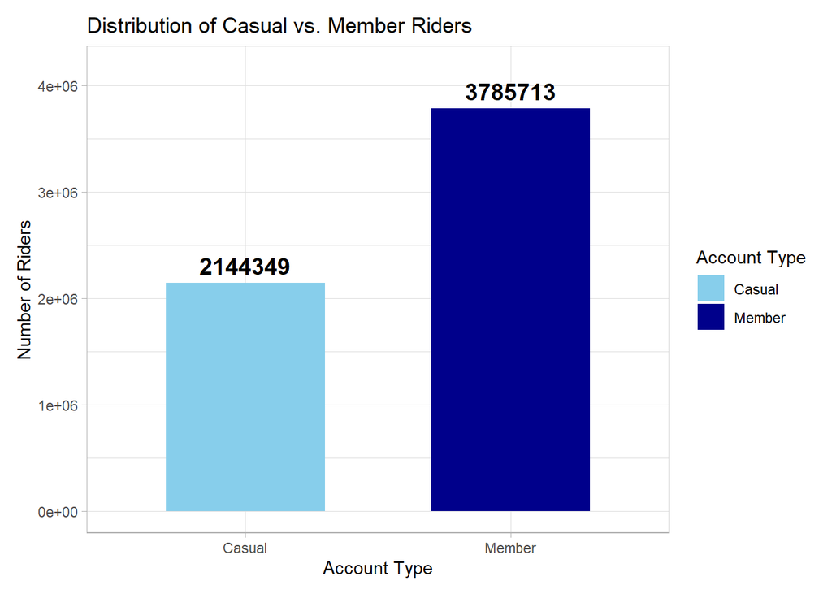

```r
# Create a Data Frame for Plotting
account_counts <- data.frame(
  account_type = c("Casual", "Member"),
  count = c(casual_count, member_count)
)

# Plot Bar Chart of rider type distribution
p <- ggplot(account_counts, aes(x = account_type,
                                y = count, fill = account_type)) +
  geom_bar(stat = "identity", width = 0.6) +  # Adjust width for aesthetics
  geom_text(aes(label = count), vjust = -0.5, size = 5, fontface = "bold") +
  labs(
    title = "Distribution of Casual vs. Member Riders",
    x = "Account Type",
    y = "Number of Riders",
    fill = "Account Type"
  ) +
  scale_fill_manual(values = c("Casual" = "skyblue", "Member" = "darkblue")) +
  theme_light() +
  expand_limits(y = max(account_counts$count) * 1.1) +
  theme(plot.margin = margin(10, 10, 10, 10))

# Display the Plot
print(p)
```

### Analysis and Key Insights

- There is an **uneven distribution** of casual(36.16%) versus member (63.84%) riders. *This* high number of casual riders** presents an opportunity for **membership conversion marketing.**
- To ensure fair comparisons, **percentages or averages** should be used instead of raw counts to avoid skewed results due to the **imbalance between casual and member totals.**

Next we will conduct an analysis of ride duration between casual and member riders.

```r
# Study the summary of ride_duration of casual riders vs annual member riders
casual_summary <-
  summary(cleaned_data$ride_duration[cleaned_data$member_casual=="casual"])
member_summary <-
  summary(cleaned_data$ride_duration[cleaned_data$member_casual == "member"])


# Create a data frame with the summary statistics
summary_data <- data.frame(
  Statistic = rep(names(casual_summary),2),
  Value = c(as.numeric(casual_summary), as.numeric(member_summary)),
  Rider_Type = rep(c("Casual", "Member"), each = length(casual_summary))
)

# Convert the data frame to wide format for table display
ride_duration_summary <- tidyr::pivot_wider(
  summary_data,
  names_from = Rider_Type,
  values_from = Value
)

# Compute Percentage Difference only for Q1, Median, Mean, and Q3
ride_duration_summary$Percent_Difference <- ifelse(
  ride_duration_summary$Statistic %in% c("1st Qu.", "Median", "Mean", "3rd Qu."),
  round(((ride_duration_summary$Casual - ride_duration_summary$Member) /
         ride_duration_summary$Member) * 100, 2),
  NA  # Leave Min and Max without percentage difference
)

# Display summary table
knitr::kable(ride_duration_summary,
             caption = "Ride Duration Summary by Rider Type (With Selective Percentage Difference)",
             digits = 2,
             format = "pipe")
```

Ride Duration Summary by Rider Type (With Selective Percentage Difference)

| Statistic | Casual | Member | Percent_Difference |
| --- | --- | --- | --- |
| Min. | 0.00 | 0.00 | NA |
| 1st Qu. | 6.78 | 5.14 | 31.95 |
| Median | 12.09 | 8.70 | 38.98 |
| Mean | 21.06 | 12.23 | 72.12 |
| 3rd Qu. | 22.69 | 14.75 | 53.78 |
| Max. | 1439.83 | 1437.77 | NA |

```r
# Display summary table
knitr::kable(ride_duration_summary,
             caption = "Ride Duration Summary by Rider Type",
             digits = 2,
             format = "pipe")
```

Ride Duration Summary by Rider Type

| Statistic | Casual | Member | Percent_Difference |
| --- | --- | --- | --- |
| Min. | 0.00 | 0.00 | NA |
| 1st Qu. | 6.78 | 5.14 | 31.95 |
| Median | 12.09 | 8.70 | 38.98 |
| Mean | 21.06 | 12.23 | 72.12 |
| 3rd Qu. | 22.69 | 14.75 | 53.78 |
| Max. | 1439.83 | 1437.77 | NA |

Bar graph of ride duration summary by rider type

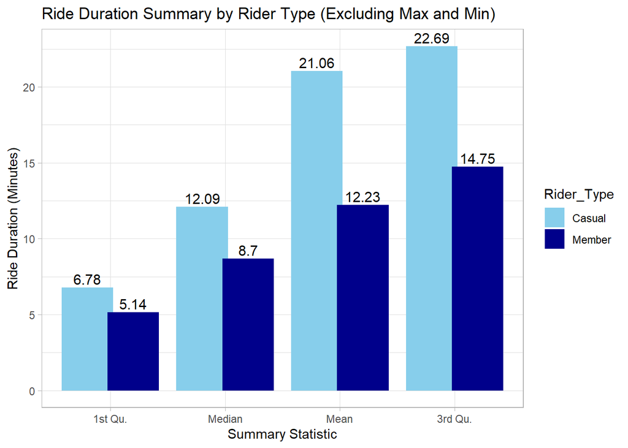

```r
# Exclude "Max" and "Min" statistics from the data
summary_data <- summary_data %>%
  filter(Statistic %in% c("1st Qu.", "Median", "Mean", "3rd Qu."))

# Ensure correct ordering of statistics
summary_data$Statistic <- factor(summary_data$Statistic,
                                 levels = c("1st Qu.", "Median", "Mean", "3rd Qu."))

# Create the dodge bar graph with labels
ggplot(summary_data, aes(x = Statistic, y = Value, fill = Rider_Type)) +
  geom_bar(stat = "identity", position = position_dodge(width = 0.8)) +
  geom_text(aes(label = round(Value, 2)),
            position = position_dodge(width = 0.8),
            vjust = -0.3, size = 4) + # Adjust vjust for padding
  scale_fill_manual(values = c("Casual" = "skyblue", "Member" = "darkblue")) +
  labs(title = "Ride Duration Summary by Rider Type (Excluding Max and Min)",
       x = "Summary Statistic",
       y = "Ride Duration (Minutes)") +
  theme_light()
```

Box plot visualization

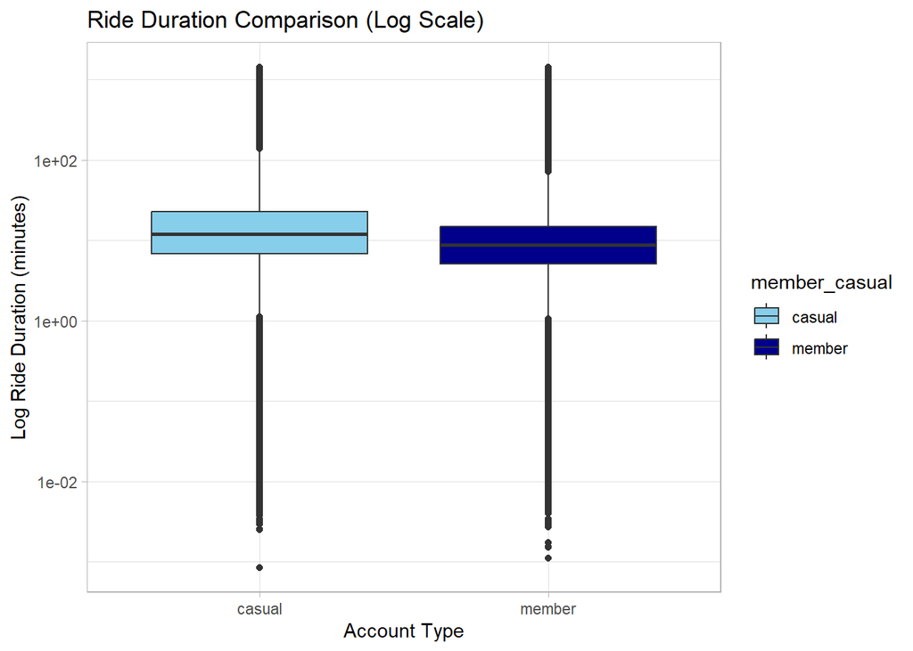

```r
# Box plot of the summaries of casual vs member ride durations
ggplot(cleaned_data, aes(x = member_casual, y = ride_duration, fill = member_casual)) +
  geom_boxplot() +
  scale_y_log10() +  # Apply log scale to y-axis
  labs(
    title = "Ride Duration Comparison (Log Scale)",
    x = "Account Type",
    y = "Log Ride Duration (minutes)"
  ) +
  scale_fill_manual(values = c("casual" = "skyblue", "member" = "darkblue")) +
  theme_light()
```

### Analysis and Inisght

- Bases on numerical and visual comparison of the summaries of casual and member ride duration, casual riders tend to use the bike longer than members.
- The box plot shows that casual riders tend to take longer rides than members.
- Member ride durations from Q1 to Q3 are contained within a **narrower range**, indicating a more **consistent** riding pattern.